# Practical Meachine Learning - Qualitative Activity Recognition of Weight Lifting Exercises

Arghya Ghosh

27 December 2015

## **Background**

Devices such as Jawbone Up, Nike FuelBand, and Fitbit now can collect large amount of data about personal activity relatively inexpensively. One thing that people regularly do is quantify how much of a particular activity they do, but they rarely quantify how well they do it.

The goal of this project is to predict the manner in which they did the exercise. This is the “classe” variable in the training set. Other variables would be used to predict classe. The following report describes the steps taken to build classification model, use of cross validation and notes on the interpretation of the results.

Classe variable consists of the following:

- Class A: exactly according to the specification
- Class B: throwing the elbows to the front
- Class C: lifting the dumbbell only halfway
- Class D: lowering the dumbbell only halfway
- Class E: throwing the hips to the front

More information is available in website: http://groupware.les.inf.puc-rio.br/har

The Write Up is divided into following sections

### **Objective**

To predict the correct way of performing weight lifting exercises.

### **Data Loading & Cleaning**

```r
library(caret)
library(corrgram)
library(rpart)
library(rpart.plot)
library(randomForest)
library(ggplot2)
```

```r
setwd("E:\\Education\\Johns_Hopkins\\8_Practical_Machine_Learning\\Week3\\WriteUp")

# Load data and perform basic row and column checks
pml_data <- read.csv("pml-training.csv", header = T, na.strings = c("NA", ""))
# Print information
cbind(Total_Row=nrow(pml_data),Total_Col=ncol(pml_data))
```

```
##      Total_Row Total_Col
## [1,]     19622       160
```

```r
# Find the numbers and percentage of NAs per column
NA_Count <- data.frame(cbind(NAs=colSums(is.na(pml_data)), Total=nrow(pml_data), Percentage=round((colSums(is.na(pml_data))/nrow(pml_data)*100),2)))
print(paste0("Total number of columns with low % of NAs: ", nrow(subset(NA_Count, NA_Count$Percentage==0))))
```

```
## [1] "Total number of columns with low % of NAs: 60"
```

Selecting the specific variables which have low percentage of NAs and are informative.

```r
# Select these 60 columns in the pml_data
pml_data <- pml_data[, colSums(is.na(pml_data))==0]
# First 7 columns do have information that would help build the model. Selcting columns 8 to 60
pml_data <- pml_data[,8:60]
# Print information
cbind(Total_Row=nrow(pml_data),Total_Col=ncol(pml_data))
```

```
##      Total_Row Total_Col
## [1,]     19622        53
```

Identifying variables with zero or near zero variance.

```r
pml_nzv <- nearZeroVar(pml_data, saveMetrics = T)
if(length(unique(pml_nzv$nzv))==1){
    print("No near zero variance variable in the dataset")
} else {
    print(paste0("No of near zero variance variables are: ", nrow(subset(pml_nzv$nzv, nzv=="TRUE"))))
}
```

```
## [1] "No near zero variance variable in the dataset"
```

```r
rm(NA_Count, pml_nzv)
```

Identifying highly correlated predictors.

```r
pml_data_corr <- pml_data[-53]
pml_data_highcorr <- findCorrelation(cor(pml_data_corr), cutoff = 0.75, verbose = F)
head(pml_data_highcorr,length(pml_data_highcorr))
```

```
##  [1] 10  1  9 22  4 36  8  2 37 35 38 21 34 23 25 12 48 19 46 31
```

```r
# High correlation column names are as follows
colnames(pml_data[,pml_data_highcorr])
```

```
##  [1] "accel_belt_z"      "roll_belt"         "accel_belt_y"
##  [4] "accel_arm_y"       "total_accel_belt"  "accel_dumbbell_z"
##  [7] "accel_belt_x"      "pitch_belt"        "magnet_dumbbell_x"
## [10] "accel_dumbbell_y"  "magnet_dumbbell_y" "accel_arm_x"
## [13] "accel_dumbbell_x"  "accel_arm_z"       "magnet_arm_y"
## [16] "magnet_belt_y"     "accel_forearm_y"   "gyros_arm_y"
## [19] "gyros_forearm_z"   "gyros_dumbbell_x"
```

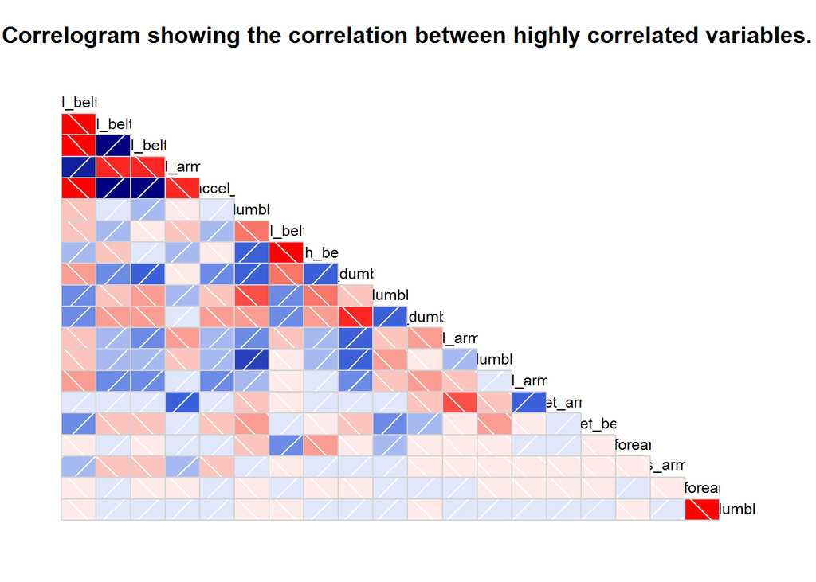

```r
# Showing the correlogram of high correlation variables in the same order of variables provided above.. Deep red is high negative correlation and deep blue is high positive correlation
pml_data_highcorr1 <- pml_data[,pml_data_highcorr]
pml_data_corr3 <- cor(pml_data_highcorr1)
# png("Corrgram.png", width = 1050, height = 1050)
corrgram(pml_data_corr3, order = F, lower.panel = panel.shade, upper.panel = NULL, text.panel = panel.txt, diag.panel=panel.minmax, cex.labels = 1.2, label.pos=c(0.3, 0.5), main="Correlogram showing the correlation between highly correlated variables.")
```

```r
# dev.off()
```

```r
pml_data_corr2 <- cor((pml_data_corr[,-pml_data_highcorr]))
rbind(Wo_Filter=summary(pml_data_corr[upper.tri(cor(pml_data_corr))]), W_Filter=summary(pml_data_corr2[upper.tri(pml_data_corr2)]))
```

```
##                Min.   1st Qu.   Median      Mean  3rd Qu.      Max.
## Wo_Filter -3600.000 -17.00000 0.430000 28.020000 49.00000 1460.0000
## W_Filter     -0.607  -0.08952 0.004661  0.008109  0.08419    0.7365
```

```r
pml_data <- pml_data[,-pml_data_highcorr]
cbind(Total_Row=nrow(pml_data),Total_Col=ncol(pml_data))
```

```
##      Total_Row Total_Col
## [1,]     19622        33
```

### **Cross Validation**

Create cross validation data sets - Train and Test.

```r
set.seed(471210)
pml_data_split <- createDataPartition(pml_data$classe, p=0.7, list = F)

pml_data_train <- pml_data[pml_data_split,]
pml_data_test <- pml_data[-pml_data_split,]
rbind(train=dim(pml_data_train), test=dim(pml_data_test))
```

```
##        [,1] [,2]
## train 13737   33
## test   5885   33
```

### **Data Preprocessing**

Centering and Scaling Train Data.

```r
pml_data_train_pp <- preProcess(pml_data_train[,-33], method = c("center", "scale","YeoJohnson"))
pml_data_train_ppp <- predict(pml_data_train_pp, newdata = pml_data_train[,-33])
pml_data_train_ppp$classe <- pml_data_train$classe # Including the classe variable in Train data
# Incorporating same changes to test data
pml_data_test_ppp <- predict(pml_data_train_pp, newdata = pml_data_test[,-33])
pml_data_test_ppp$classe <- pml_data_test$classe # Including the classe variable in Test data
```

### **Model Building 1: Decision Tree**

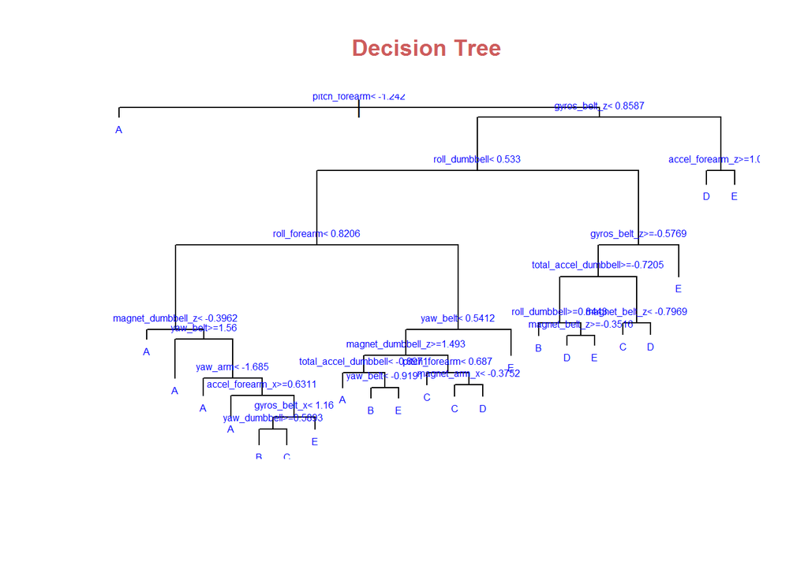

```r
# Model Building: Decision Tree
set.seed(1227)
d_tree <- rpart(classe~., data = pml_data_test_ppp, method = "class")
# png("Decision Tree.png", width = 1050, height = 1050)
plot(d_tree)
text(d_tree, pretty = 0, cex=.5, col="blue")
title(main = "Decision Tree", col.main="indianred")
```

```r
# dev.off()
```

**Model Accuracy: Decision Tree**

```r
# Model Validation
d_tree_val <- predict(d_tree, pml_data_test_ppp, type = "class")
d_tree_val_confusionm <- confusionMatrix(d_tree_val, pml_data_test_ppp$classe)
d_tree_val_confusionm
```

```
## Confusion Matrix and Statistics
##
##           Reference
## Prediction    A    B    C    D    E
##          A 1460  259   42   83   73
##          B   30  523   47   61  112
##          C   50  213  899  191  194
##          D  133  138   34  569   51
##          E    1    6    4   60  652
##
## Overall Statistics
##
##                Accuracy : 0.6972
##                  95% CI : (0.6853, 0.7089)
##     No Information Rate : 0.2845
##     P-Value [Acc > NIR] : < 2.2e-16
##
##                   Kappa : 0.6156
##  Mcnemar's Test P-Value : < 2.2e-16
##
## Statistics by Class:
##
##                      Class: A Class: B Class: C Class: D Class: E
## Sensitivity            0.8722  0.45917   0.8762  0.59025   0.6026
## Specificity            0.8915  0.94732   0.8666  0.92766   0.9852
## Pos Pred Value         0.7616  0.67658   0.5811  0.61514   0.9018
## Neg Pred Value         0.9461  0.87950   0.9707  0.92036   0.9167
## Prevalence             0.2845  0.19354   0.1743  0.16381   0.1839
## Detection Rate         0.2481  0.08887   0.1528  0.09669   0.1108
## Detection Prevalence   0.3257  0.13135   0.2629  0.15718   0.1229
## Balanced Accuracy      0.8818  0.70325   0.8714  0.75895   0.7939
```

By observing the insample **Accuracy** of **0.6972** and confusion matrix, we find that the model is **not able to classify the qualitative weight lifting activities properly**.

### **Model Building 2: Random Forest**

Testing out Randomforest model on the train data set and predicting the value in test data set.

```
## mtry = 5  OOB error = 0.82%
## Searching left ...
## mtry = 4     OOB error = 0.93%
## -0.1428571 0.01
## Searching right ...
## mtry = 7     OOB error = 0.83%
## -0.01785714 0.01
```

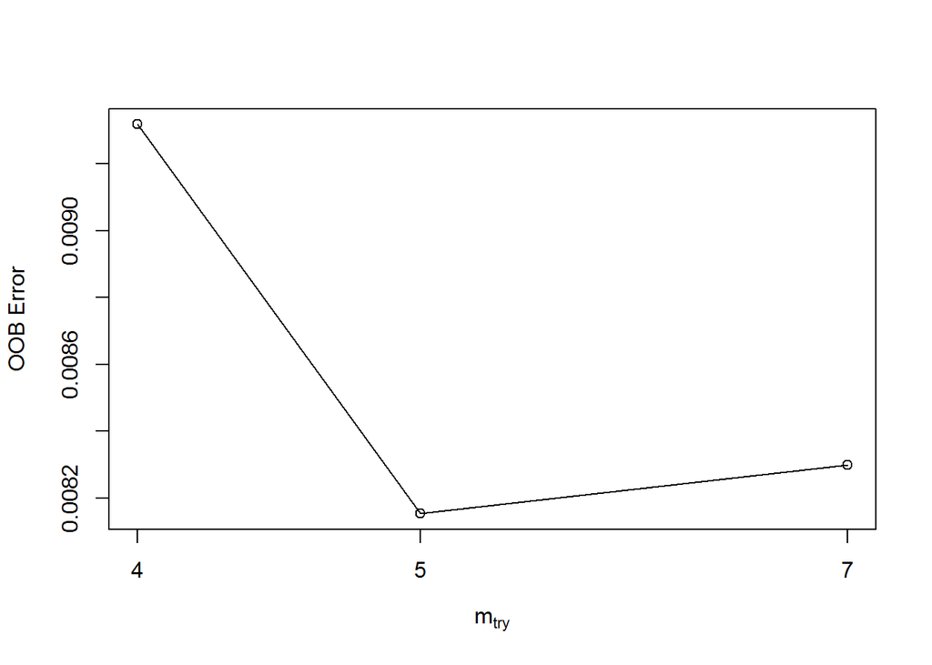

```r
set.seed(371210)
rf_mtry <- tuneRF(pml_data_train_ppp[,-33], pml_data_train_ppp$classe, ntreeTry = 150, stepFactor = 1.5, improve = 0.01, trace = T, plot = T, doBest = F)
```

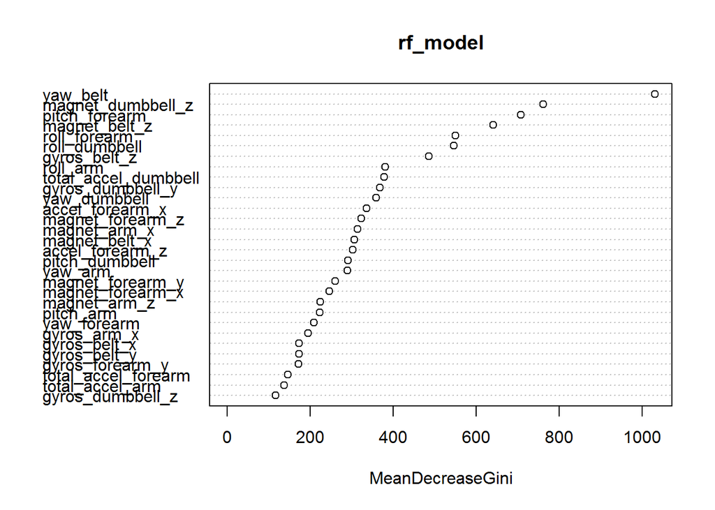

```r
rf_mtry1 <- rf_mtry[as.numeric(which.min(rf_mtry[,"OOBError"])),"mtry"]
rf_model <- randomForest(classe~., data = pml_data_train_ppp)
rf_model_val <- predict(rf_model, pml_data_test_ppp, type = "class")
varImpPlot(rf_model, type = 2)
```

```r
# Checkig the accuracy of the model on test data set
rf_model_confusionm <- confusionMatrix(rf_model_val, pml_data_test_ppp$classe)
rf_model_confusionm
```

```
## Confusion Matrix and Statistics
##
##           Reference
## Prediction    A    B    C    D    E
##          A 1674    5    0    0    0
##          B    0 1131    9    0    0
##          C    0    2 1012    7    0
##          D    0    0    5  956    5
##          E    0    1    0    1 1077
##
## Overall Statistics
##
##                Accuracy : 0.9941
##                  95% CI : (0.9917, 0.9959)
##     No Information Rate : 0.2845
##     P-Value [Acc > NIR] : < 2.2e-16
##
##                   Kappa : 0.9925
##  Mcnemar's Test P-Value : NA
##
## Statistics by Class:
##
##                      Class: A Class: B Class: C Class: D Class: E
## Sensitivity            1.0000   0.9930   0.9864   0.9917   0.9954
## Specificity            0.9988   0.9981   0.9981   0.9980   0.9996
## Pos Pred Value         0.9970   0.9921   0.9912   0.9896   0.9981
## Neg Pred Value         1.0000   0.9983   0.9971   0.9984   0.9990
## Prevalence             0.2845   0.1935   0.1743   0.1638   0.1839
## Detection Rate         0.2845   0.1922   0.1720   0.1624   0.1830
## Detection Prevalence   0.2853   0.1937   0.1735   0.1641   0.1833
## Balanced Accuracy      0.9994   0.9955   0.9923   0.9948   0.9975
```

## **Out of sample prediction**

```r
# Out of Sample Test
setwd("E:\\Education\\Johns_Hopkins\\8_Practical_Machine_Learning\\Week3\\WriteUp")
pml_data_test<- read.csv("pml-testing.csv", header = T, na.strings = c("NA", "","")) # Loading test data
pml_data_test<- pml_data_test[, colSums(is.na(pml_data_test))==0] # NA treatment
pml_data_test <- pml_data_test[,8:60] # Informative columns included
pml_data_test <- pml_data_test[,-c(10,1,9,22,4,36,8,2,37,35,38,21,34,23,25,12,48,19,46,31)] # Highly correlated variables are excluded
pml_data_test <- predict(pml_data_train_pp, newdata = pml_data_test[,-33]) # Centering and scaling
pml_data_test_val <- predict(rf_model, pml_data_test, type = "class") # Randomforest prediction

# Use the provided to code to create a function for making multiple files
pml_write_files = function(x){
  n = length(x)
  for(i in 1:n){
    filename = paste0("problem_id_",i,".txt")
    write.table(x[i],file=filename,quote=FALSE,row.names=FALSE,col.names=FALSE)
  }
}
```

The result would be provided by code: **pml_write_files(pml_data_test_val)**